# hw2

## Question 3.1

Using the same data set (credit_card_data.txt or credit_card_data-headers.txt) as in Question 2.2, use the ksvm or kknn function to find a good classifier: (a) using cross-validation (do this for the k-nearest-neighbors model; SVM is optional); and (b) splitting the data into training, validation, and test data sets (pick either KNN or SVM; the other is optional).

# Import Libraries

```r
library(kernlab)
library(rmarkdown)
library(data.table)
library(stats)
library(gtools)
library(kknn)
```

# Read data

```r
data<-read.table("/Assignments/ISYE-6501/week1/data\ 2.2/credit_card_data-headers.txt", header=TRUE)
datamatrix <- as.matrix(data)
```

# Split Data into Train, Validate and Test

```r
m <- dim(data)[1]
test_sample <- sample(1:m, size = round(m*0.2), replace = FALSE)

# 20% Testing
testing <- data[test_sample, ]

#80% Training and Validation
learning <- data[-test_sample, ]

  dim(learning)
```

```
## [1] 523  11
```

```r
  dim(testing)
```

```
## [1] 131  11
```

```r
  mlearning<-dim(learning)[1]
```

K-fold cross validation. K=10. Split data into K equal parts

```r
k<-10
dsplits <- split(as.data.frame(learning[-1:-(mlearning %% k),]), rep(1:k, each = round(mlearning / k)))

# get the indexes for the dsplits list to create the combinations of training (tdata) and validation (vdata) datasets

numbers <- c(1:k)
dComb<-combinations(k,k-1,numbers[1:k])
maxSum<-sum(seq(1:k))

# validation data index
vIndex<- maxSum-rowSums(dComb)
```

# Function to train model based on the algorithm

```r
trainAndPredict <- function(tData,vData,modelName,knnVal,cval){
  if(modelName == "ksvm"){
    model <- NULL
    model <- ksvm(x=tData[,1:10],y=tData[,11], type="C-svc",  kernel="vanilladot", C=cval, scaled=TRUE)
    a <- colSums(model@xmatrix[[1]] * model@coef[[1]])
    a0 <- -model@b
    pred <- predict(model,vData[, 1:10])
    acc = sum(pred == vData[,11]) / nrow(vData)
    return (acc)
  }
  else if(modelName == "knn"){

   predicted <- rep(0,(nrow(vData)))

      m = dim(vData)[1]

      kknnmodel_2 <-NULL
      kknnmodel_2 <- kknn(R1~.,tData,vData,k=knnVal, kernel="triangular", scale=TRUE)
      fit <- fitted(kknnmodel_2)
      predicted = fit
      acc = sum(predicted == vData[,11])/m

     return (acc)

  }

    return (0)
}

trainLoop <- function(val) {
  results <- list()
  accKsvm<- array()
  for (i in 1:k) {
   #training data
    tData<-as.matrix(rbindlist(dsplits[-vIndex[i]]))
   #validation data
    vData<-as.matrix(rbindlist(dsplits[vIndex[i]]))
    # accuracy array
    accKsvm[i]=trainAndPredict(tData,vData,"ksvm",0,cval=val)
    }

  return(data.table(Cval=val,avgAccuracy=sum(accKsvm)/length(accKsvm)))

  }
```

# Call the train function to train models for KSVM and KNN

```r
#KNN
kVal <-seq(2,15)
count=0
results_merged_knn<-list()
for(val in kVal){
 count = count+1
 accKnn <- array()
  for (i in 1:k) {
    #training data
    tData<-as.data.frame(rbindlist(dsplits[-vIndex[i]]))

     #validation data
    vData<-as.data.frame(rbindlist(dsplits[vIndex[i]]))

    #accuracy array
    accKnn[i]=trainAndPredict(tData,vData,"knn",knnVal = val,0)

  }
 results_merged_knn[[count]] = data.table(kVal=val,avgAccuracy=sum(accKnn)/length(accKnn))
}

knn_top_5<-rbindlist(results_merged_knn)[order(-avgAccuracy)[1:5]]

#KSVM
  kcount<-0
  results_merged=list()
  cval <- c(25,80,95,100,500,10000)
  count= 0
  for ( val in cval) {
    kcount=kcount+1

     results_merged[[kcount]] = trainLoop(val)

  }
 ksvm_top_5<- rbindlist(results_merged)[order(-avgAccuracy)[1:5]]
```

# Top 5 Results for each model

```r
  knn_top_5
```

```
##    kVal avgAccuracy
## 1:    2   0.6846154
## 2:    3   0.6346154
## 3:    4   0.5923077
## 4:    5   0.5326923
## 5:    6   0.5096154
```

```r
  ksvm_top_5
```

```
##    Cval avgAccuracy
## 1:   25   0.8673077
## 2:   80   0.8673077
## 3:   95   0.8673077
## 4:  100   0.8673077
## 5:  500   0.8673077
```

# Final training on all of training data

Clearly SVM performs better than KNN hence training a model with the entire training data and veryfying the performance using the test data

```r
    finalAccuracy=trainAndPredict(as.matrix(learning),as.matrix(testing),"ksvm",0,cval=25)
    finalAccuracy
```

```
## [1] 0.8396947
```

## Question 4.1

Describe a situation or problem from your job, everyday life, current events, etc., for which a clustering model would be appropriate. List some (up to 5) predictors that you might use.

1. Priority of emails to respond based on its importance and bucket them as high, medium, low
- Predictors:
  - From email ID
  - subject
  - sentiment of the email
  - time of the day
  - Amount of work required to be done before responding.

## Question 4.2

Use the R function kmeans to cluster the points as well as possible. Report the best combination of predictors, your suggested value of k, and how well your best clustering predicts flower type. ### Read data

```r
data("iris")
head(iris)
```

```
##   Sepal.Length Sepal.Width Petal.Length Petal.Width Species
## 1          5.1         3.5          1.4         0.2  setosa
## 2          4.9         3.0          1.4         0.2  setosa
## 3          4.7         3.2          1.3         0.2  setosa
## 4          4.6         3.1          1.5         0.2  setosa
## 5          5.0         3.6          1.4         0.2  setosa
## 6          5.4         3.9          1.7         0.4  setosa
```

### Lets view the relation of each variable to the overall dataset

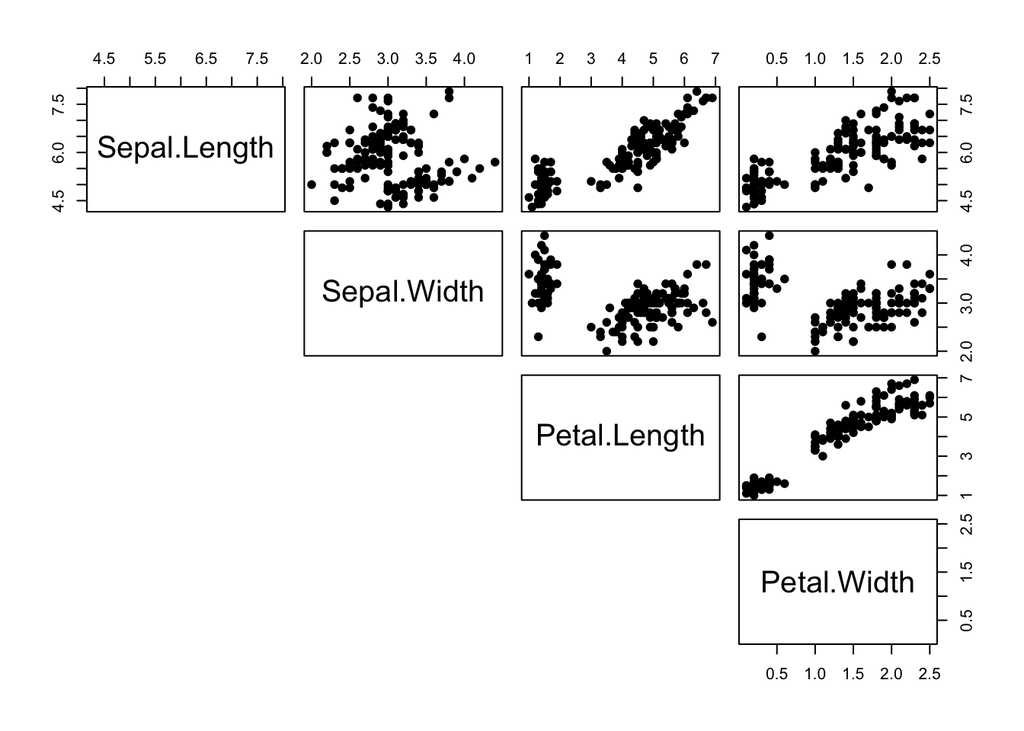

```r
pairs(iris[,1:4], pch = 19, lower.panel = NULL)
```

Lets train models on the following combinations which as per the above graph may produce distinct clusters

1. Sepal.Width, Petal.Width
2. Sepal.Length, Petal.Width
3. Sepal.Length, Petal.length
4. Petal.Length, Petal.Width

Lets Plot the elbow graph to Figure out the optimal value of K for the combinations. Recall that the elbow graph is a plot of sum of squared errors within a group and number of groups

```r
library(dplyr)
```

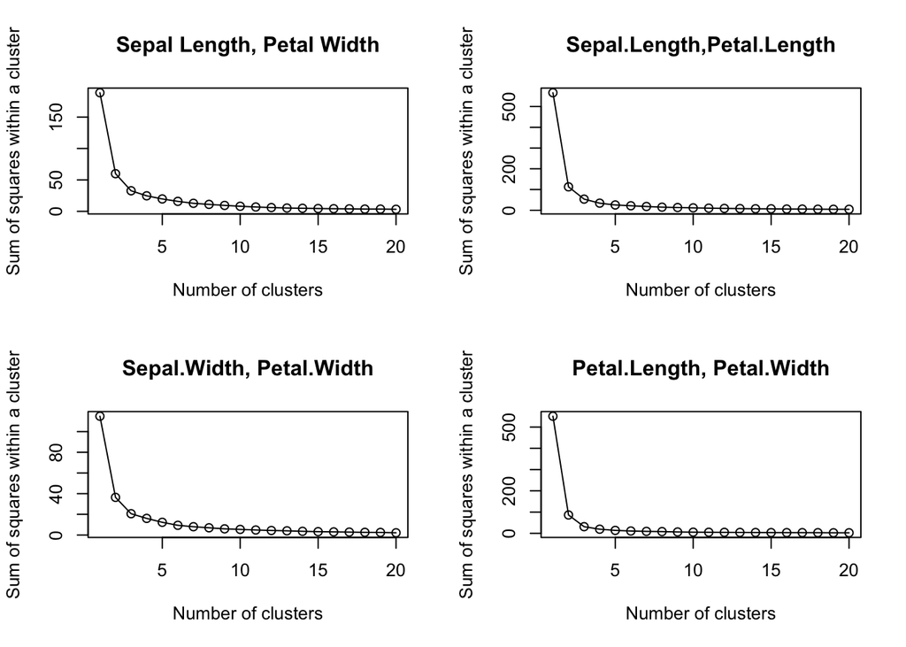

```r
trainModels <- function(data,label) {
  num_of_clusters <-20
plot_data<- array()
between_cluster<-array()
for (i in 1:num_of_clusters){
    cl <- kmeans(data,i,nstart = 20)
    plot_data[i] <- (cl$tot.withinss)
}

plot(1:num_of_clusters, plot_data, type="o" ,xlab="Number of clusters",
                     ylab="Sum of squares within a cluster", main=label)

}

par(mfrow=c(2,2))
trainModels(select(iris,Sepal.Length, Petal.Width),"Sepal Length, Petal Width")
trainModels(select(iris, Sepal.Length,Petal.Length),"Sepal.Length,Petal.Length")
trainModels(select(iris, Sepal.Width, Petal.Width),"Sepal.Width, Petal.Width")
trainModels(select(iris, Petal.Length, Petal.Width),"Petal.Length, Petal.Width")
```

It seems Petal.Length and Petal.Width are a good choise of attributes due to the quick convergence of the elbow graph, above, at K=3, the elbow flattens out and beyond that has no significance change.

Train a K-means model with K=3

```r
cl <- kmeans(select(iris,Petal.Length, Petal.Width),3,nstart = 20)
cl
```

```
## K-means clustering with 3 clusters of sizes 48, 52, 50
##
## Cluster means:
##   Petal.Length Petal.Width
## 1     5.595833    2.037500
## 2     4.269231    1.342308
## 3     1.462000    0.246000
##
## Clustering vector:
##   [1] 3 3 3 3 3 3 3 3 3 3 3 3 3 3 3 3 3 3 3 3 3 3 3 3 3 3 3 3 3 3 3 3 3 3 3 3 3
##  [38] 3 3 3 3 3 3 3 3 3 3 3 3 3 2 2 2 2 2 2 2 2 2 2 2 2 2 2 2 2 2 2 2 2 2 2 2 2
##  [75] 2 2 2 1 2 2 2 2 2 1 2 2 2 2 2 2 2 2 2 2 2 2 2 2 2 2 1 1 1 1 1 1 2 1 1 1 1
## [112] 1 1 1 1 1 1 1 1 2 1 1 1 1 1 1 2 1 1 1 1 1 1 1 1 1 1 1 2 1 1 1 1 1 1 1 1 1
## [149] 1 1
##
## Within cluster sum of squares by cluster:
## [1] 16.29167 13.05769  2.02200
##  (between_SS / total_SS =  94.3 %)
##
## Available components:
##
## [1] "cluster"      "centers"      "totss"        "withinss"     "tot.withinss"
## [6] "betweenss"    "size"         "iter"         "ifault"
```

A 94.3 % of between_SS / total_SS implies that the cluster is a good fit.

Lets look at how the model compares to the label “Species”

```r
table(cl$cluster,iris$Species)
```

```
##
##     setosa versicolor virginica
##   1      0          2        46
##   2      0         48         4
##   3     50          0         0
```

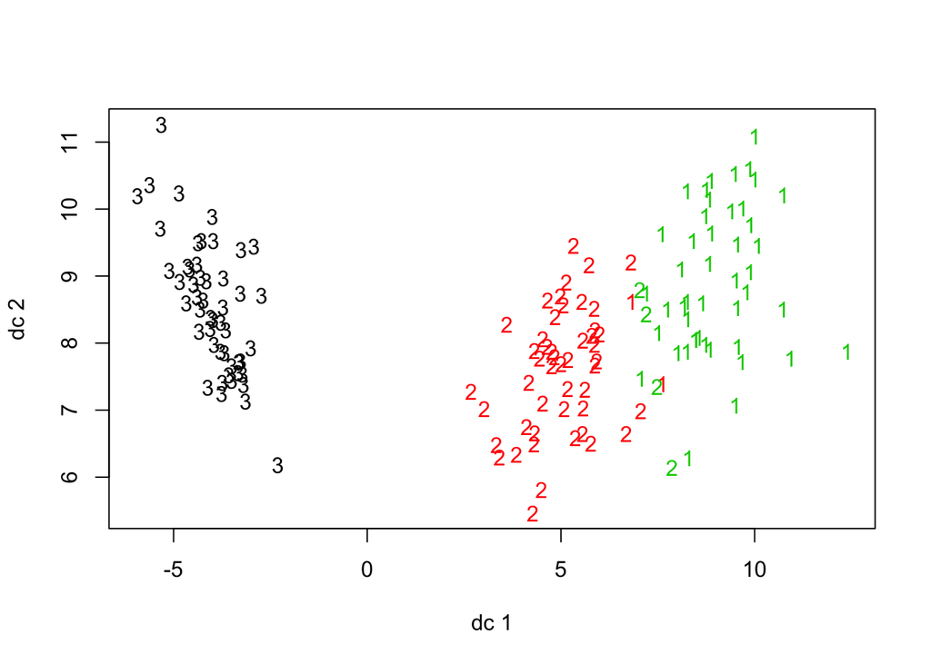

```r
library(fpc)
plotcluster(iris[,1:4], cl$cluster,col=iris$Species, xlab = )
```

We can see that the cluster has correctly classified setosa flowers, there are 2 misclassifications of veriscolor and 4 misclassifications of virginica.